# Задание на лабораторную работу №2. Pandas и основы python

## Общее задание

1. Сгенерировать с использованием библиотеки pandas csv файл, содержащий 3 столбца: $x_1$, $x_2$, $y$ (> 400 строк, генерация с использованием функции linspace). Вид функции определяется вариантом (диапазон выбирается студентом).
2. Открыть файл с использованием библиотеки pandas и построить графики: $y(x_1)$ ($x_2$ - константа), $y(x_2)$ ($x_1$ - константа). Графики необходимо построить с использованием matplotlib (для функции y отобразить точки на графике).
3. Вывести для каждого столбца $(x_1, x_2, y)$: среднее, минимальное и максимальное значения.
4. Сохранить в новый csv файл те строки, для которых выполняется условие: $x_1$ меньше среднее $x_1$ или $x_2$ меньше среднее $x_2$
5. С использованием mplot3D построить 3D график функции $y(x_1, x_2)$ в отдельном окне.

## Варианты

1. $y = sin(x_1 + x_2)$
2. $y = cos(x_1 + x_2)$
3. $y = tan(x_1 + x_2) * sin(x_1)$
4. $y = 2 * x_1^2 + 3x_2^2$
5. $y = 5 * log(x_1) * log(2 * x_2)$
6. $y = 5 * log(x_1) * x_2^2$
7. $y = cos(x_1) * x_2^3$
8. $y = \frac{3}{(2 + e^{-2x})}$
9. $y = cos(x_1 + x_2) * x_2 ^ 2$
10. $y = \frac{x_2}{(1 + e^{-x_1})}$
11. $y = \frac{3 * x_1}{(1 - e^{-x_2})}$
12. $y = 0.01 * tan(x_1) * x_2^2$
13. $y = x_1^6 + x_2^2 + x_1^3 + 4x_2 + 5$
14. $y = cos(x_1) * x_2^3$
15. $y = tan(x_1) * ctg(x_2)$
16. $y = \frac{sin(x_1)}{(1 + e^{-2x_2})}$
17. $y = \frac{cos(x_1)}{(1 + e^{-2x_1})}$
18. $y = \frac{tan(x_1)}{(3 + e^{-2x_2})}$
19. $y = \frac{ctg(x_1)}{(2 + e^{-2x_2})}$
20. $y = \frac{x_1^2}{(1 + e^{-2x_2})}$

# Задание 1

```python
import pandas as pd
import math
```

```python
x1 = pd.np.linspace(1, 10, 20)
x2 = pd.np.linspace(-20, -1, 50)
x = pd.np.array(pd.np.meshgrid(x1, x2)).T.reshape(-1, 2)
y = pd.np.cos(x[:,0] + x[:,1])

df = pd.DataFrame(pd.np.vstack([x[:,0], x[:,1], y]).swapaxes(0, 1), columns=['x_1', 'x_2', 'y'])
df.to_csv('data.csv', index=False)
# x
df
```

|  | x_1 | x_2 | y |
| --- | --- | --- | --- |
| 0 | 1.0 | -20.000000 | 0.988705 |
| 1 | 1.0 | -19.612245 | 0.971974 |
| 2 | 1.0 | -19.224490 | 0.810924 |
| 3 | 1.0 | -18.836735 | 0.529470 |
| 4 | 1.0 | -18.448980 | 0.169399 |
| 5 | 1.0 | -18.061224 | -0.215823 |
| 6 | 1.0 | -17.673469 | -0.569001 |
| 7 | 1.0 | -17.285714 | -0.837693 |
| 8 | 1.0 | -16.897959 | -0.982005 |
| 9 | 1.0 | -16.510204 | -0.980509 |
| 10 | 1.0 | -16.122449 | -0.833428 |
| 11 | 1.0 | -15.734694 | -0.562600 |
| 12 | 1.0 | -15.346939 | -0.208237 |
| 13 | 1.0 | -14.959184 | 0.177045 |
| 14 | 1.0 | -14.571429 | 0.536039 |
| 15 | 1.0 | -14.183673 | 0.815443 |
| 16 | 1.0 | -13.795918 | 0.973769 |
| 17 | 1.0 | -13.408163 | 0.987511 |
| 18 | 1.0 | -13.020408 | 0.854628 |
| 19 | 1.0 | -12.632653 | 0.594850 |
| 20 | 1.0 | -12.244898 | 0.246749 |
| 21 | 1.0 | -11.857143 | -0.137990 |
| 22 | 1.0 | -11.469388 | -0.502239 |
| 23 | 1.0 | -11.081633 | -0.791917 |
| 24 | 1.0 | -10.693878 | -0.964011 |
| 25 | 1.0 | -10.306122 | -0.992969 |
| 26 | 1.0 | -9.918367 | -0.874491 |
| 27 | 1.0 | -9.530612 | -0.626170 |
| 28 | 1.0 | -9.142857 | -0.284875 |
| 29 | 1.0 | -8.755102 | 0.098719 |
| ... | ... | ... | ... |
| 970 | 10.0 | -12.244898 | -0.624196 |
| 971 | 10.0 | -11.857143 | -0.282449 |
| 972 | 10.0 | -11.469388 | 0.101235 |
| 973 | 10.0 | -11.081633 | 0.469888 |
| 974 | 10.0 | -10.693878 | 0.768772 |
| 975 | 10.0 | -10.306122 | 0.953509 |
| 976 | 10.0 | -9.918367 | 0.996670 |
| 977 | 10.0 | -9.530612 | 0.891845 |
| 978 | 10.0 | -9.142857 | 0.654600 |
| 979 | 10.0 | -8.755102 | 0.320160 |
| 980 | 10.0 | -8.367347 | -0.061817 |
| 981 | 10.0 | -7.979592 | -0.434616 |
| 982 | 10.0 | -7.591837 | -0.742883 |
| 983 | 10.0 | -7.204082 | -0.940847 |
| 984 | 10.0 | -6.816327 | -0.999115 |
| 985 | 10.0 | -6.428571 | -0.909034 |
| 986 | 10.0 | -6.040816 | -0.683981 |
| 987 | 10.0 | -5.653061 | -0.357370 |
| 988 | 10.0 | -5.265306 | 0.022303 |
| 989 | 10.0 | -4.877551 | 0.398664 |
| 990 | 10.0 | -4.489796 | 0.715832 |
| 991 | 10.0 | -4.102041 | 0.926713 |
| 992 | 10.0 | -3.714286 | 0.999997 |
| 993 | 10.0 | -3.326531 | 0.924801 |
| 994 | 10.0 | -2.938776 | 0.712291 |
| 995 | 10.0 | -2.551020 | 0.394021 |
| 996 | 10.0 | -2.163265 | 0.017246 |
| 997 | 10.0 | -1.775510 | -0.362089 |
| 998 | 10.0 | -1.387755 | -0.687662 |
| 999 | 10.0 | -1.000000 | -0.911130 |

1000 rows × 3 columns

# Задание 2

```python
from matplotlib import pyplot as plt
```

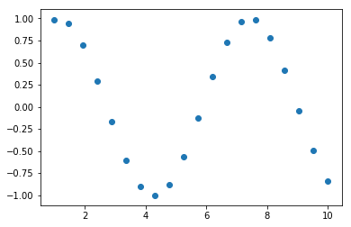

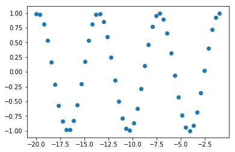

```python
df = pd.read_csv('data.csv')

df_1 = df[df['x_2']==x2[0]]
plt.scatter(df_1['x_1'], df_1['y'])
plt.show()

df_2 = df[df['x_1']==x1[0]]
plt.scatter(df_2['x_2'], df_2['y'])
plt.show()
```

# Задание 3

```python
df_agg = df.agg(['mean', 'min', 'max'])
df_agg
```

|  | x_1 | x_2 | y |
| --- | --- | --- | --- |
| mean | 5.5 | -10.5 | 0.001668 |
| min | 1.0 | -20.0 | -1.000000 |
| max | 10.0 | -1.0 | 1.000000 |

# Задание 4

```python
df_filtered = df[(df['x_1']<df_agg['x_1']['mean']) | (df['x_2']<df_agg['x_2']['mean'])]
df_filtered.to_csv('data_filtered.csv')
df_filtered
```

|  | x_1 | x_2 | y |
| --- | --- | --- | --- |
| 0 | 1.000000 | -20.000000 | 0.988705 |
| 1 | 1.000000 | -19.612245 | 0.971974 |
| 2 | 1.000000 | -19.224490 | 0.810924 |
| 3 | 1.000000 | -18.836735 | 0.529470 |
| 4 | 1.000000 | -18.448980 | 0.169399 |
| 5 | 1.000000 | -18.061224 | -0.215823 |
| 6 | 1.000000 | -17.673469 | -0.569001 |
| 7 | 1.000000 | -17.285714 | -0.837693 |
| 8 | 1.000000 | -16.897959 | -0.982005 |
| 9 | 1.000000 | -16.510204 | -0.980509 |
| 10 | 1.000000 | -16.122449 | -0.833428 |
| 11 | 1.000000 | -15.734694 | -0.562600 |
| 12 | 1.000000 | -15.346939 | -0.208237 |
| 13 | 1.000000 | -14.959184 | 0.177045 |
| 14 | 1.000000 | -14.571429 | 0.536039 |
| 15 | 1.000000 | -14.183673 | 0.815443 |
| 16 | 1.000000 | -13.795918 | 0.973769 |
| 17 | 1.000000 | -13.408163 | 0.987511 |
| 18 | 1.000000 | -13.020408 | 0.854628 |
| 19 | 1.000000 | -12.632653 | 0.594850 |
| 20 | 1.000000 | -12.244898 | 0.246749 |
| 21 | 1.000000 | -11.857143 | -0.137990 |
| 22 | 1.000000 | -11.469388 | -0.502239 |
| 23 | 1.000000 | -11.081633 | -0.791917 |
| 24 | 1.000000 | -10.693878 | -0.964011 |
| 25 | 1.000000 | -10.306122 | -0.992969 |
| 26 | 1.000000 | -9.918367 | -0.874491 |
| 27 | 1.000000 | -9.530612 | -0.626170 |
| 28 | 1.000000 | -9.142857 | -0.284875 |
| 29 | 1.000000 | -8.755102 | 0.098719 |
| ... | ... | ... | ... |
| 920 | 9.526316 | -12.244898 | -0.911857 |
| 921 | 9.526316 | -11.857143 | -0.688944 |
| 922 | 9.526316 | -11.469388 | -0.363736 |
| 923 | 9.526316 | -11.081633 | 0.015479 |
| 924 | 9.526316 | -10.693878 | 0.392396 |
| 950 | 10.000000 | -20.000000 | -0.839072 |
| 951 | 10.000000 | -19.612245 | -0.982479 |
| 952 | 10.000000 | -19.224490 | -0.980009 |
| 953 | 10.000000 | -18.836735 | -0.832028 |
| 954 | 10.000000 | -18.448980 | -0.560507 |
| 955 | 10.000000 | -18.061224 | -0.205763 |
| 956 | 10.000000 | -17.673469 | 0.179534 |
| 957 | 10.000000 | -17.285714 | 0.538173 |
| 958 | 10.000000 | -16.897959 | 0.816904 |
| 959 | 10.000000 | -16.510204 | 0.974342 |
| 960 | 10.000000 | -16.122449 | 0.987110 |
| 961 | 10.000000 | -15.734694 | 0.853312 |
| 962 | 10.000000 | -15.346939 | 0.592815 |
| 963 | 10.000000 | -14.959184 | 0.244297 |
| 964 | 10.000000 | -14.571429 | -0.140494 |
| 965 | 10.000000 | -14.183673 | -0.504425 |
| 966 | 10.000000 | -13.795918 | -0.793458 |
| 967 | 10.000000 | -13.408163 | -0.964680 |
| 968 | 10.000000 | -13.020408 | -0.992666 |
| 969 | 10.000000 | -12.632653 | -0.873262 |
| 970 | 10.000000 | -12.244898 | -0.624196 |
| 971 | 10.000000 | -11.857143 | -0.282449 |
| 972 | 10.000000 | -11.469388 | 0.101235 |
| 973 | 10.000000 | -11.081633 | 0.469888 |
| 974 | 10.000000 | -10.693878 | 0.768772 |

750 rows × 3 columns

# Задание 5

```python
from mpl_toolkits.mplot3d import Axes3D
from matplotlib import cm
```

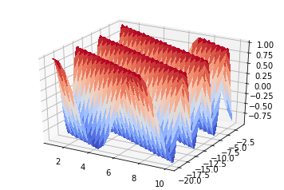

```python
fig = plt.figure()
ax = fig.gca(projection='3d')
xx1, xx2 = pd.np.meshgrid(x1, x2)
z = pd.np.cos(xx1+xx2)
surf = ax.plot_surface(xx1, xx2, z, cmap=cm.coolwarm,
                       linewidth=0, antialiased=False)
```